# Apprendre la Programmation (en R) avec les LLMs

Elias Bouacida

12 octobre 2026

# Introduction

## Bienvenue ! 🚀

**Apprendre la Programmation (en R) avec les LLMs**

**🤖 LLM = Votre Assistant**

LLM : Large Language Model, aussi connu sous le nom d’IA générative

Ex : ChatGPT, Claude, Mistral, etc.

**📊 R = Langage Statistique**

Pour analyser, visualiser, calculer

**🎯 Objectif = Collaboration**

Programmer AVEC l’IA générative intelligemment

## Sondage 📊

**Levez la main si vous avez déjà (Pas de jugement ! 😊)…**

- Utilisé un LLM (ChatGPT, Claude, etc) ? 🙋‍♀️
- Demandé leur aide pour un devoir ? 📝
- Copié-collé une de leur réponse sans la comprendre ? 😅
- Fait confiance aveuglément à un LLM ? 🤖
- Payé pour un LLM ?
- Programmé dans n’importe quel langage de programmation ? 💻

# Pourquoi ce cours ? 🎯

## Que va-t-on apprendre ?

### Comment utilisez-vous des LLMs ?

### L’approche ici

- Poser les BONNES questions
- Vérifier et corriger les erreurs
- Comprendre les réponses
- Utiliser le LLM comme partenaire

**Objectif :** Autonomie et esprit critique

## Démonstration : Prompt

### Prompt 1

```
"Fais-moi des statistiques sur mes données"
```

- Problème : Trop vague !
- Quelles données ?
- Quelles statistiques ?
- Quel format de sortie ?

### Prompt 2

```
"J'ai 10 notes d'étudiants :
12, 15, 18, 14, 16, 13, 17, 11, 19, 15.
Calcule la moyenne, médiane et l'écart-type
en R avec des commentaires explicatifs."
```

**Résultat :** Code précis et commenté !

## Objectif du cours

- Apprendre à utiliser R et Rstudio
- Apprendre à utiliser les principales librairies (aussi appelées paquets) de R pour l’analyse de données et les statistiques (le tidyverse)
- Vous apprendre à utiliser des LLMs pour faire cela

# R et Rstudio ? 📊

## R et RStudio : Des outils

### R

- Langage de programmation
- Spécialisé en analyse de données
- Dérive d’un langage antérieur appelé S https://fr.wikipedia.org/wiki/S_(langage)
- Est un [logiciel libre](https://fr.wikipedia.org/wiki/Logiciel_libre)

### RStudio = L’Interface (IDE)

- Environnement convivial
- Facilite l’écriture de code R
- Intègre tous les outils nécessaires

## Exemples concrets d’usage

- **Analyser un sondage** : “Quel pourcentage préfère le chocolat ?”
- **Créer des graphiques** : Histogrammes, courbes, diagrammes
- **Calculs statistiques** : Moyennes, corrélations, tests, régressions
- **Données géographiques** : Cartes
- **Nettoyer des données** : Corriger, organiser, structurer
- **Prédictions simples** : “Quelle sera la prochaine tendance ?”

## Premier aperçu du code R

```r
# Créer une liste de notes
notes <- c(15, 12, 18, 14, 16, 13, 17)
# Calculer la moyenne
moyenne <- mean(notes)
# Afficher le résultat
print(paste("La moyenne est :", moyenne))
```

```
[1] "La moyenne est : 15"
```

**C’est tout ! Pas si compliqué, non ?**

# Comment ça marche avec un LLM ?

## Le processus en 4 étapes

1. 🎯 Formuler une question précise
   - Au lieu de “fais-moi des calculs”
   - Dire “calcule la moyenne de ces 5 notes : 12, 15, 18, 14, 16”
2. 🤖 Recevoir et comprendre la réponse
   - Le LLM vous donne du code + des explications (si vous lui demandez)
3. 🧪 Tester et vérifier
   - Exécuter le code, voir si ça marche, comprendre pourquoi
4. ✨ Améliorer si nécessaire
   - Corriger les erreurs, adapter à vos besoins

## Exemple

Votre demande (à votre LLM préféré)

```
"J'ai des données de vente par mois :
Janvier : 1500€, Février : 2000€, Mars : 1800€
Crée un graphique en barres avec R"
```

Essayez !

## Exemple (réponse possible)

```r
# Données de vente
mois <- c("Janvier", "Février", "Mars")
ventes <- c(1500, 2000, 1800)

# Créer le graphique
barplot(ventes, names.arg = mois,
        main = "Ventes par mois",
        ylab = "Montant (€)")
```

## Le résultat

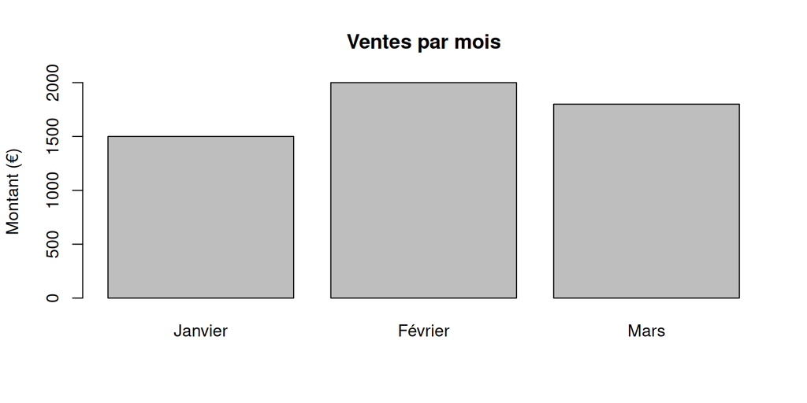

```r
# Testons le code !
mois <- c("Janvier", "Février", "Mars")
ventes <- c(1500, 2000, 1800)

# Créer le graphique
barplot(ventes, names.arg = mois,
        main = "Ventes par mois",
        ylab = "Montant (€)")
```

## Les Erreurs : Vos Amies !

**Principe pédagogique :** Les erreurs sont des occasions d’apprentissage, pas des échecs !

- 🎯 **Développer votre esprit critique**
- 🔍 **Apprendre à déboguer**
- 🤖 **Comprendre les limites des LLM**
- 💪 **Gagner en autonomie**
- 🧠 **Mémoriser par l’expérience**

# Organisation du Cours

## 5 Séances de 3 heures 📅

Le cours est structuré en 2 phases progressives sur 5 séances de 3h.

## Phase 1 : Fondations 🌱 (Séances 1-3)

**Objectif :** Maîtriser le dialogue avec un LLM et les concepts R de base

### Séance 1 : Premiers pas avec R

- Découvrir RStudio et son interface
- Comprendre les concepts de base : objets, types, vecteurs
- Utiliser des fonctions intégrées
- Créer son premier script
- Commencer son journal de bord

### Séance 2 : Données et visualisations

- Importer des données réelles (fichiers CSV)
- Explorer des dataframes
- Calculer des statistiques descriptives
- Créer des visualisations simples
- Apprendre à déboguer efficacement

### Séance 3 : Automatisation et fonctions

- Utiliser des conditions (`if/else`)
- Créer des boucles (`for`, `while`)
- Écrire vos propres fonctions
- Combiner tous les concepts appris

## Phase 2 : Application 🚀 (Séances 4-5)

**Objectif :** Analyser de vraies données en autonomie

### Séance 4 : Données tabulaires et graphiques avancés

- Maîtriser les `data.frames` complexes
- Nettoyage de données (casse, formats, incohérences)
- Visualisations avec `ggplot2`
- Créer des fonctions de visualisation réutilisables

### Séance 5 : Projet personnel intégré

- Choix et cadrage d’un projet personnel
- Analyse complète de A à Z en autonomie
- Présentation des résultats aux pairs

## Progression pédagogique

- **Séances 1-3** → Bases : concepts fondamentaux et autonomie technique
- **Séances 4-5** → Application : projets personnels et analyses complètes

**À la fin du cours, vous serez capable de :** analyser des données en autonomie, créer vos propres outils, automatiser vos analyses et utiliser les LLMs comme de véritables partenaires de travail.

## Structure d’une séance type

### 🎭 Présentation

**30-60 min**

- Concepts du jour
- Démonstrations en direct
- Exemples concrets

### 💻 Pratique

**90-120 min**

- Exercices sur machine
- Aide individuelle
- Déboguing collectif

### 🤝 Partage

**30 min**

- Retours d’expérience
- Solutions créatives

# Évaluation 📊

## Une évaluation bienveillante

**Cours à validation** : L’objectif est d’évaluer votre progression, pas de vous piéger !

### Composition de la note

La validation dépend de 3 composantes :

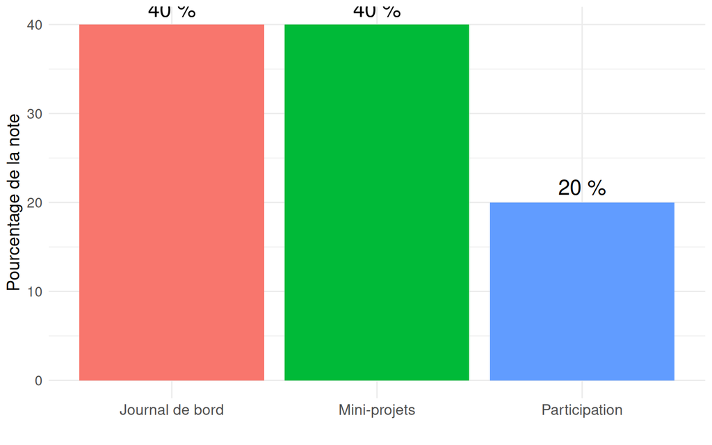

## 📓 Journal de bord (40%)

Document votre apprentissage tout au long du semestre.

**Pour chaque séance, notez :**

- Les **prompts** utilisés avec les LLMs (copier-coller exact)
- Les **réponses** obtenues (copier-coller, pas de captures d’écran)
- Votre **compréhension** avec vos propres mots
- Les **difficultés** et erreurs rencontrées
- Les **solutions** trouvées
- Le **code** produit et commenté

**Soyez honnête !**

Documentez vos échecs comme vos réussites. C’est votre progression qui compte.

## 🎯 Mini-projets (40%)

Rendus de fin de séance à soumettre sur Moodle.

**Critères :** Code fonctionnel, commenté, résout le problème posé

## 👥 Participation (20%)

Votre engagement pendant les séances.

- **Présence active** : Vous travaillez sur les exercices
- **Entraide** : Vous aidez vos camarades ou demandez de l’aide
- **Déboguing collectif** : Vous partagez vos solutions
- **Questions** : Vous posez des questions pertinentes

**Pas de stress !**

La participation, ce n’est pas parler beaucoup, c’est être engagé dans votre apprentissage.

# Questions & Discussion 💬

## Vos interrogations

**Quelles sont vos questions ?**

- Sur l’utilisation des LLM ?
- Sur le langage R ?
- Sur l’organisation du cours ?
- Sur l’évaluation ?

**Pas de question bête !** Nous sommes tous là pour apprendre ensemble

## Ressources disponibles

### 🔗 Liens utiles

- Installation R/RStudio : https://moodle.univ-paris8.fr/course/section.php?id=134073
- Utilisation de R/Rstudio en ligne : https://datalab.sspcloud.fr/ (Utilisez votre compte étudiant Paris 8 pour vous connecter)
- Guide des prompts efficaces : https://www.francenum.gouv.fr/guides-et-conseils/intelligence-artificielle/generation-de-contenus-texte-image-son-video/comment-0

## Contact et ressources

- 📧 **Email :** elias.bouacida@univ-paris8.fr
- 🌐 **Espace de cours :** [Moodle](https://moodle.univ-paris8.fr/course/view.php?id=18115)
- 🌐 **Cours :** [Cours](https://eliasbcd.github.io/rl3/)
- Bureau : Bâtiment D, Salle D115
- Permanences : Mardi 14h-16h, Mercredi 14h-16h